# Análise Exploratória do Campeonato Brasileiro de Futebol (2003-2023)

Nikolas N. Figueiredo

11 de junho de 2024

# 1 **Introdução**

Este relatório surge como um estudo do Campeonato Brasileiro Série A, que é um dos objetos de estudo da minha dissertação de mestrado em Estatística Aplicada e Biometria. As análises foram feitas em linguagem R utilizando a IDE RStudio e o relatório foi gerado em R Markdown. Os dados utilizados foram disponibilizados por DUQUE (2023), por meio da plataforma Kaggle. Ainda, parte fundamental do trabalho de um estatístico é criar e manipular dados. Assim, este relatório busca deixar esse processo explícito, tanto como forma de valorizar essas ferramentas quanto para garantir a replicabilidade dessa análise.

## 1.1 **Objetivos do Relatório**

O objetivo deste relatório é apresentar uma análise exploratória dos dados do Campeonato Brasileiro Série A, com foco em identificar padrões, tendências e insights que possam ser úteis para análises futuras e para a tomada de decisões estratégicas na elaboração de modelos de predição.

### 1.1.1 **Objetivos Específicos**

Ainda deseja-se:

- Observar quais times participaram dessa competição.
- Contabilizar a participação dos times e sua relevância para a competição.
- Entender a distribuição dos gols na competição.
- Visualizar a distribuição dos jogos em relação aos estádios e aos estados do Brasil.

## 1.2 **Pacotes Utilizados**

```r
#Pacotes
library(tidyverse)
```

# 2 **Primeiro Contato com os Dados**

Leitura dos dados.

```r
br <- read_csv("br.csv")
```

Observando a estrutura dos dados, é possível visualizar uma tabela com **8.405** linhas e **17** colunas. Cada uma dessas linhas representa uma partida, contendo informações sobre a data, hora, local da partida; informações dos times que se enfrentaram, a formação técnica e o técnico responsável; e informações sobre o resultado do confronto, como placar e time vencedor.

```r
glimpse(br)
```

```
## Rows: 8,405
## Columns: 17
## $ ID                 <dbl> 1, 2, 3, 4, 5, 6, 7, 8, 9, 10, 11, 12, 13, 14, 15, …
## $ rodata             <dbl> 1, 1, 1, 1, 1, 1, 1, 1, 1, 1, 1, 1, 2, 2, 2, 2, 2, …
## $ data               <chr> "29/03/2003", "29/03/2003", "30/03/2003", "30/03/20…
## $ ano                <dbl> 2003, 2003, 2003, 2003, 2003, 2003, 2003, 2003, 200…
## $ hora               <time> 16:00:00, 16:00:00, 16:00:00, 16:00:00, 16:00:00, …
## $ mandante           <chr> "Guarani", "Athletico-PR", "Flamengo", "Goias", "In…
## $ visitante          <chr> "Vasco", "Gremio", "Coritiba", "Paysandu", "Ponte P…
## $ formacao_mandante  <chr> NA, NA, NA, NA, NA, NA, NA, NA, NA, NA, NA, NA, NA,…
## $ formacao_visitante <chr> NA, NA, NA, NA, NA, NA, NA, NA, NA, NA, NA, NA, NA,…
## $ tecnico_mandante   <chr> NA, NA, NA, NA, NA, NA, NA, NA, NA, NA, NA, NA, NA,…
## $ tecnico_visitante  <chr> NA, NA, NA, NA, NA, NA, NA, NA, NA, NA, NA, NA, NA,…
## $ vencedor           <chr> "Guarani", "Athletico-PR", "-", "-", "-", "Criciuma…
## $ arena              <chr> "Brinco de Ouro", "Arena da Baixada", "Maracanã", "…
## $ mandante_Placar    <dbl> 4, 2, 1, 2, 1, 2, 2, 0, 2, 1, 2, 0, 1, 0, 0, 3, 1, …
## $ visitante_Placar   <dbl> 2, 0, 1, 2, 1, 0, 2, 0, 2, 1, 2, 3, 1, 0, 1, 1, 2, …
## $ mandante_Estado    <chr> "SP", "PR", "RJ", "GO", "RS", "SC", "RS", "CE", "MG…
## $ visitante_Estado   <chr> "RJ", "RS", "PR", "PA", "SP", "RJ", "SP", "BA", "SP…
```

**Observação**: Ao contrário do que o comando acima sugere, as colunas de formação tática e do técnico responsável pelos times mandante e visitante não são colunas inteiramente compostas por “NA”. As informações sobre o técnico começaram a ser coletadas a partir de 2014, e em 2015 foram adicionadas informações sobre a formação dos times. Como essas variáveis não têm impacto significativo nos objetivos da análise, a abordagem adotada foi: manter os dados existentes, não adotar nenhuma técnica de completamento dos dados faltantes e apenas observar essas métricas a partir dos anos indicados.

```r
sum(table(br$formacao_mandante))
## [1] 3431
sum(table(br$formacao_visitante))
## [1] 3431
sum(table(br$tecnico_mandante))
## [1] 3795
sum(table(br$tecnico_visitante))
## [1] 3795
```

# 3 **Análise dos Dados**

Esta análise está dividida em três perspectivas: primeiro em relação ao formato do campeonato; segundo, em relação aos times e suas métricas; e por fim, em relação aos estádios e estados.

## 3.1 **O Campeonato e Seu Formato**

Estão representados nesse banco de dados, os campeonatos de 2003 a 2023, totalizando **21** edições, **8.405** partidas e **818** rodadas. A 69ª edição está acontecendo em 2024, seguindo a mesma estrutura dos anos anteriores. Uma observação importante é sobre o campeonato de 2016, que foi encerrado com apenas 379 partidas. Isso aconteceu devido à tragédia com o time da Chapecoense.

```r
# Número de times por ano
num_times_por_ano <- br |>
  select(ano, mandante, visitante) |>
  gather(key = "tipo", value = "time", -ano) |>
  distinct(ano, time) |>
  group_by(ano) |>
  summarise(`Número de times` = n(), .groups = "drop")

# Número de rodadas por ano
num_rodadas_por_ano <- br |>
  group_by(ano, rodata) |>
  summarise(`Número de rodadas` = n_distinct(rodata), .groups = "drop") |>
  group_by(ano) |>
  summarise(`Número de rodadas` = n(), .groups = "drop")

# Contar o número de jogos por ano e renomear as colunas
jogos_por_ano <- br |>
  count(ano) |>
  rename('Ano' = ano, 'Número de jogos' = n)

# Combinar as informações de número de times e número de rodadas com o número de jogos por ano
resultados_completos <- jogos_por_ano |>
  left_join(num_times_por_ano, by = c("Ano" = "ano")) |>
  left_join(num_rodadas_por_ano, by = c("Ano" = "ano"))

# Ajustar a exibição para mostrar todas as linhas do tibble no console
print(resultados_completos, n = Inf)
```

```
## # A tibble: 21 × 4
##      Ano `Número de jogos` `Número de times` `Número de rodadas`
##    <dbl>             <int>             <int>               <int>
##  1  2003               552                24                  46
##  2  2004               552                24                  46
##  3  2005               462                22                  42
##  4  2006               380                20                  38
##  5  2007               380                20                  38
##  6  2008               380                20                  38
##  7  2009               380                20                  38
##  8  2010               380                20                  38
##  9  2011               380                20                  38
## 10  2012               380                20                  38
## 11  2013               380                20                  38
## 12  2014               380                20                  38
## 13  2015               380                20                  38
## 14  2016               379                20                  38
## 15  2017               380                20                  38
## 16  2018               380                20                  38
## 17  2019               380                20                  38
## 18  2020               380                20                  38
## 19  2021               380                20                  38
## 20  2022               380                20                  38
## 21  2023               380                20                  38
```

## 3.2 **Os Times e Suas Métricas**

Sobre os times que compõem o banco, é possível dizer a partir da observação da tabela abaixo:

- **45 times** participaram pelo menos de um ano de competição.
- Os times têm uma tendência de se alternarem entre os anos de competição.
- **América de Natal, Barueri, Brasiliense, CSA, Grêmio Prudente, Ipatinga, Joinville e Santo André** participaram somente uma vez desse campeonato.
- **Flamengo, Santos e São Paulo** estiveram presentes em todas as edições observadas.
- O **Santos**, com **1.178 gols** ao longo de 21 campeonatos, é o time que mais fez gols, seguido pelo **Flamengo** com **1.169 gols**.
- O **América de Natal** e o **CSA** atingiram apenas **24 gols** em sua única participação na competição, sendo esse o menor valor dessa variável.
- O **Joinville** destaca-se por sua defesa, que sofreu apenas **48 gols**, apresentando a melhor performance nesse aspecto, em sua breve passagem pela Série A em 2015.
- O **Fluminense** se destacou negativamente por sua defesa, uma vez que sofreu **1.032 gols**. Entretanto, isso não foi suficiente para tirá-lo da Série A do campeonato. Ainda sobre gols sofridos, em segundo lugar está o **Santos**, com **982 gols**.
- Quando se trata de vitórias, **São Paulo** lidera com **365** triunfos, refletindo uma consistência notável ao longo do período analisado.
- O desempenho na tabela de empates é liderado pelo **Corinthians** e também pelo **São Paulo**, ambos com **229 empates**.
- O **Fluminense**, com **283** derrotas, destaca-se como o time que mais enfrentou adversidades. Logo em seguida está o **Athletico Paranaense** com **282** derrotas.

```r
# Contar o número de anos de participação como mandante
part_ano <- br |>
  select(ano, mandante) |>
  distinct() |>
  count(mandante, name = 'Part')

# Combinar as contagens de mandante e visitante para obter o número total de jogos por time
times <- c(br$mandante, br$visitante)
tab_freq <- table(sort(times)) |>
  as.data.frame() |>
  rename('Time' = Var1, 'Nº jogos' = Freq)

# Contar o número de vitórias, empates e derrotas para cada time
vitórias <- br |>
  mutate(
    vencedor = ifelse(mandante_Placar > visitante_Placar, mandante, ifelse(mandante_Placar < visitante_Placar, visitante, NA))
  ) |>
  filter(!is.na(vencedor)) |>
  count(vencedor, name = 'Vit')

empates<- br |>
  filter(mandante_Placar == visitante_Placar) |>
  select(mandante,visitante)

empates <- c(empates$mandante, empates$visitante)|>
  sort()|>
  table() |>
  as.data.frame()|>
  rename("time" = Var1, "Emp" = Freq)


derrotas <- br |>
  mutate(
    perdedor = ifelse(mandante_Placar < visitante_Placar, mandante, ifelse(mandante_Placar > visitante_Placar, visitante, NA))
  ) |>
  filter(!is.na(perdedor)) |>
  count(perdedor, name = 'Der')

# Contar o número de gols feitos e sofridos por cada time
gols_feitos <- br |>
  group_by(mandante) |>
  summarise(Gols_Feitos_Mandante = sum(mandante_Placar, na.rm = TRUE)) |>
  full_join(
    br |>
      group_by(visitante) |>
      summarise(Gols_Feitos_Visitante = sum(visitante_Placar, na.rm = TRUE)),
    by = c("mandante" = "visitante")
  ) |>
  mutate(Gols_Feitos = Gols_Feitos_Mandante + Gols_Feitos_Visitante) |>
  select(mandante, Gols_Feitos)

gols_sofridos <- br |>
  group_by(mandante) |>
  summarise(Gols_Sofridos_Mandante = sum(visitante_Placar, na.rm = TRUE)) |>
  full_join(
    br |>
      group_by(visitante) |>
      summarise(Gols_Sofridos_Visitante = sum(mandante_Placar, na.rm = TRUE)),
    by = c("mandante" = "visitante")
  ) |>
  mutate(Gols_Sofridos = Gols_Sofridos_Mandante + Gols_Sofridos_Visitante) |>
  select(mandante, Gols_Sofridos)

# Combinar a contagem de anos de participação com a contagem de jogos e resultados
tab_freq <- tab_freq |>
  left_join(part_ano, by = c("Time" = "mandante")) |>
  left_join(vitórias, by = c("Time" = "vencedor")) |>
  left_join(empates, by = c("Time" = "time")) |>
  left_join(derrotas, by = c("Time" = "perdedor")) |>
  left_join(gols_feitos, by = c("Time" = "mandante")) |>
  left_join(gols_sofridos, by = c("Time" = "mandante")) |>
  replace_na(list('Vit' = 0, 'Emp' = 0, 'Der' = 0, 'Gols_Feitos' = 0, 'Gols_Sofridos' = 0))

# Ajustar a exibição para mostrar todas as linhas do tibble no console
print(tab_freq)
```

```
##               Time Nº jogos Part Vit Emp Der Gols_Feitos Gols_Sofridos
## 1       America-MG      228    6  58  61 109         227           332
## 2       America-RN       38    1   4   5  29          24            80
## 3     Athletico-PR      780   20 309 189 282        1032           965
## 4      Atletico-GO      266    7  72  79 115         288           363
## 5      Atletico-MG      779   20 327 199 253        1131           978
## 6             Avai      266    7  66  73 127         274           415
## 7            Bahia      426   11 127 121 178         480           565
## 8          Barueri       38    1  12  13  13          59            52
## 9      Botafogo-RJ      696   18 247 190 259         876           881
## 10      Bragantino      152    4  55  50  47         203           180
## 11     Brasiliense       42    1  10  12  20          49            68
## 12           Ceara      266    7  72  92 102         277           317
## 13     Chapecoense      265    7  70  77 118         261           359
## 14     Corinthians      780   20 326 229 225         999           832
```

[output cut: 31 more lines]

Agora, observando essas métricas ponderadas pela quantidade de participações dos times, nota-se que:

- **São Paulo**, **Palmeiras** e **Internacional** lideram o ranking de vitórias médias com, respectivamente, **17,38**; **17,32** e **16,95 vitórias** por ano de competição.
- **América de Natal**, **Prudente** e **Joinville** não ultrapassaram **7 vitórias**.
- **Ceará**, **Guarani** e **Barueri** são os times que em média mais empataram, com, respectivamente, **13,14**; **13** e **13 empates** por ano de competição.
- **América de Natal**, **Santa Cruz** e **CSA** são os times com as maiores médias de derrotas, com, respectivamente, **29**; **23,5** e **22 derrotas** por ano de competição.
- **São Paulo**, **Corinthians** e **Palmeiras** obtiveram as menores médias de derrotas.
- Surpreendentemente, **Paysandu** é o time que mais fez gols em média, com **64,33 gols por ano**, foram **193 gols** em apenas **3 anos** de participações no campeonato. Seguido por **Barueri**, **Palmeiras** e **Atlético Mineiro** com **59**; **56,68** e **56,55 gols por ano**, respectivamente.
- Da mesma forma que os jogadores do **Paysandu** fizeram muitos gols, também sofreram muitos gols, com uma média de **81,67 gols por ano**. Em seguida estão o **América de Natal**, **Santa Cruz** e **Brasiliense**.
- Os times que obtiveram os menores números de gols médios foram o **Cuiabá**, **Corinthians** e **São Paulo**, nessa ordem.

```r
tab_freq_media <- tab_freq |>
  mutate(
    Vit_Med = round(Vit / Part , 2),
    Emp_Med = round(Emp / Part , 2),
    Der_Med = round(Der / Part , 2),
    Gols_F_Med = round(Gols_Feitos / Part , 2),
    Gols_S_Med = round(Gols_Sofridos / Part , 2)
  )

tab_freq_media <- tab_freq_media |>
  select(
    Time, `Nº jogos`, Part,
    Vit_Med, Emp_Med, Der_Med,
    Gols_F_Med, Gols_S_Med
  )

print(tab_freq_media)
```

```
##               Time Nº jogos Part Vit_Med Emp_Med Der_Med Gols_F_Med Gols_S_Med
## 1       America-MG      228    6    9.67   10.17   18.17      37.83      55.33
## 2       America-RN       38    1    4.00    5.00   29.00      24.00      80.00
## 3     Athletico-PR      780   20   15.45    9.45   14.10      51.60      48.25
## 4      Atletico-GO      266    7   10.29   11.29   16.43      41.14      51.86
## 5      Atletico-MG      779   20   16.35    9.95   12.65      56.55      48.90
## 6             Avai      266    7    9.43   10.43   18.14      39.14      59.29
## 7            Bahia      426   11   11.55   11.00   16.18      43.64      51.36
## 8          Barueri       38    1   12.00   13.00   13.00      59.00      52.00
## 9      Botafogo-RJ      696   18   13.72   10.56   14.39      48.67      48.94
## 10      Bragantino      152    4   13.75   12.50   11.75      50.75      45.00
## 11     Brasiliense       42    1   10.00   12.00   20.00      49.00      68.00
## 12           Ceara      266    7   10.29   13.14   14.57      39.57      45.29
## 13     Chapecoense      265    7   10.00   11.00   16.86      37.29      51.29
## 14     Corinthians      780   20   16.30   11.45   11.25      49.95      41.60
```

[output cut: 31 more lines]

### 3.2.1 **Gols e Sua Distribuição**

Nesses 21 anos de competição foram feitos **21.586 gols**, que foram distribuídos de 0 a 7. A **média** e o **desvio padrão** são, respectivamente, **1,28** e **1,16 gols**.

```r
# Criação do vetor de gols combinando os placares de mandantes e visitantes
gols <- c(br$mandante_Placar, br$visitante_Placar)

cat("Número total de gols =", sum(gols),"\n","\n",

    "Média de gols = ", round(mean(gols),2),"\n",
    "desvio padrão =", round(sd(gols),2),"\n","\n",

    "Média dos gols do mandante =", round(mean(br$mandante_Placar),2), "\n",
    "desvio padrão dos gols do mandante=", round(sd(br$mandante_Placar),2),"\n","\n",

    "Média dos gols do visitante =", round(mean(br$visitante_Placar),2), "\n",
    "desvio padrão dos gols do visitante =", round(sd(br$visitante_Placar),2)
    )
```

```
## Número total de gols = 21586
##
##  Média de gols =  1.28
##  desvio padrão = 1.16
##
##  Média dos gols do mandante = 1.54
##  desvio padrão dos gols do mandante= 1.23
##
##  Média dos gols do visitante = 1.03
##  desvio padrão dos gols do visitante = 1.03
```

Os valores exatos de sua distribuição estão representados abaixo, e também por meio de um gráfico de agulhas.

```r
# Tabela de frequências dos gols
gols_freq <- data.frame(table(gols))
colnames(gols_freq) <- c("Gols", "Frequência")

print(gols_freq)
```

```
##   Gols Frequência
## 1    0       4798
## 2    1       5889
## 3    2       3727
## 4    3       1607
## 5    4        586
## 6    5        150
## 7    6         43
## 8    7         10
```

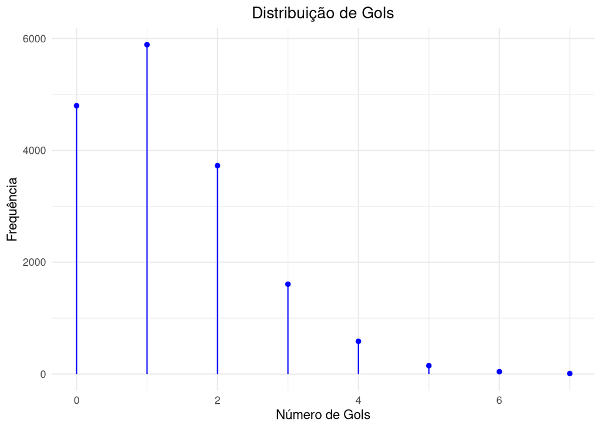

```r
# Converter a coluna Gols para numérica
gols_freq$Gols <- as.numeric(as.character(gols_freq$Gols))

# Plotagem do gráfico de agulhas
ggplot(gols_freq, aes(x = Gols, y = Frequência)) +
  geom_segment(aes(x = Gols, xend = Gols, y = 0, yend = Frequência), color = "blue") +
  geom_point(color = "blue") +
  theme_minimal() +
  labs(title = "Distribuição de Gols",
       x = "Número de Gols",
       y = "Frequência") +
  theme(plot.title = element_text(hjust = 0.5))
```

Ao observarmos a distribuição do número de gols, é bastante plausível tentar associar essa distribuição a outra distribuição teórica que se aproxime dos dados. Nesse sentido, ARRUDA (2000) afirma que o número de gols de uma partida segue uma distribuição de Poisson. Por isso, foi plotado abaixo o comparativo dos dados observados e dos valores obtidos de uma distribuição de Poisson com λ = 1,28.

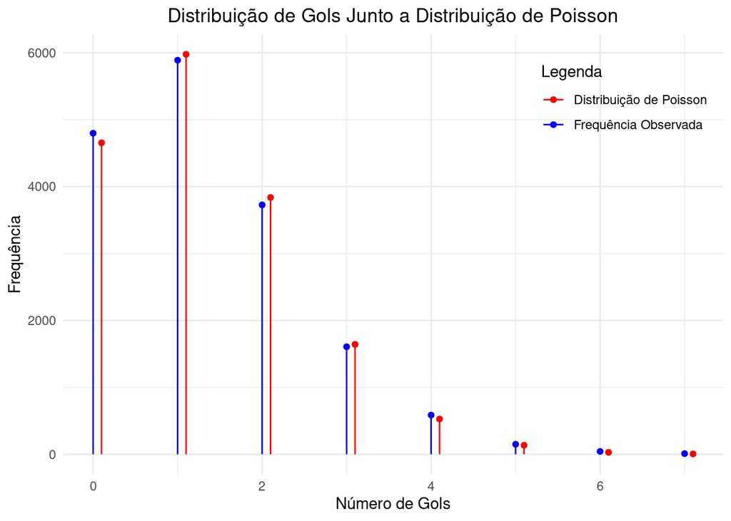

```r
# Criação do vetor de gols combinando os placares de mandantes e visitantes
gols <- c(br$mandante_Placar, br$visitante_Placar)

# Tabela de frequências dos gols
gols_freq <- data.frame(table(gols))
colnames(gols_freq) <- c("Gols", "Frequência")

# Converter a coluna Gols para numérica
gols_freq$Gols <- as.numeric(as.character(gols_freq$Gols))

# Cálculo dos valores da distribuição de Poisson com média 1.284117
lambda <- mean(gols)
max_gols <- max(gols_freq$Gols)
gols_poisson <- 0:max_gols
poisson_prob <- dpois(gols_poisson, lambda) * sum(gols_freq$Frequência)

# Criação do data frame para a distribuição de Poisson
poisson_df <- data.frame(Gols = gols_poisson, Frequência = poisson_prob)

# Criar o gráfico com legenda
ggplot() +
  geom_segment(data = gols_freq, aes(x = Gols, xend = Gols, y = 0, yend = Frequência, color = "Frequência Observada")) +
  geom_point(data = gols_freq, aes(x = Gols, y = Frequência, color = "Frequência Observada")) +
  geom_segment(data = poisson_df, aes(x = Gols + 0.1, xend = Gols + 0.1, y = 0, yend = Frequência, color = "Distribuição de Poisson")) +
  geom_point(data = poisson_df, aes(x = Gols + 0.1, y = Frequência, color = "Distribuição de Poisson")) +
  scale_color_manual(values = c("Frequência Observada" = "blue", "Distribuição de Poisson" = "red")) +
  theme_minimal() +
  labs(title = "Distribuição de Gols Junto a Distribuição de Poisson",
       x = "Número de Gols",
       y = "Frequência",
       color = "Legenda") +
  theme(plot.title = element_text(hjust = 0.5),
        legend.position = c(0.85, 0.85))
```

## 3.3 **Os Estádios e Seus Estados**

Outra perspectiva que podemos observar nos dados é quanto ao local de realização das partidas. Assim, nota-se que:

- Em ordem decrescente, os 10 principais estádios do campeonato são: **Maracanã, Mineirão, Morumbi, Arena da Baixada, Vila Belmiro, Engenhão, Couto Pereira, Serra Dourada, Pacaembu e São Januário**.
- Em cada edição do campeonato, acontecem em torno de **30 partidas** no Maracanã, enquanto no Independência ocorrem apenas **4 ou menos**.
- Os estádios: **Antônio Guimarães, Castelão de São Luís, Juiz de Fora, Luiz Lacerda, Mj José Levi Sobrinho, Primeiro de Maio São Bernardo do Campo e Vila Olímpica** sediaram apenas uma partida dessa competição.

```r
# Contar a frequência de jogos em cada arena
freq_campos <- br |>
  count(arena) |>
  mutate(
    n_pond = n/21
  )|>
rename("Campo" = arena, "Nº partidas"= n, "Nº partidas/ Nº camp"= n_pond)

# Ajustar a exibição para mostrar todas as linhas do tibble no console
print(freq_campos, n = Inf)
```

```
## # A tibble: 95 × 3
##    Campo                                  `Nº partidas` `Nº partidas/ Nº camp`
##    <chr>                                          <int>                  <dbl>
##  1 Aflitos                                           75                 3.57
##  2 Alfredo Jaconi                                   146                 6.95
##  3 Allianz Parque                                   150                 7.14
##  4 Anacleto Campanella                               88                 4.19
##  5 Antônio Accioly                                   44                 2.10
##  6 Antônio Guimarães                                  1                 0.0476
##  7 Arena Barueri                                     47                 2.24
##  8 Arena Castelão                                   250                11.9
##  9 Arena Condá                                      132                 6.29
## 10 Arena Joinville                                   22                 1.05
## 11 Arena MRV                                          9                 0.429
## 12 Arena Pantanal                                    66                 3.14
```

[output cut: 83 more lines]

De maneira mais ampla, podemos observar o impacto que cada estado tem nessa competição. Por exemplo:

- **São Paulo** foi o estado que sediou mais jogos, totalizando mais de 2 mil jogos nesses 21 anos. Em seguida, estão os estados do Rio de Janeiro, Rio Grande do Sul, Minas Gerais e Paraná.
- A região Sudeste tem forte influência no campeonato, ao contrário da região Norte e Nordeste.

```r
# Lista de todos os estados do Brasil com nomes completos
estados_brasil <- data.frame(
  Sigla = c("AC", "AL", "AP", "AM", "BA", "CE", "DF", "ES", "GO", "MA", "MT", "MS", "MG", "PA", "PB", "PR", "PE", "PI", "RJ", "RN", "RS", "RO", "RR", "SC", "SP", "SE", "TO"),
  Estado = c("Acre", "Alagoas", "Amapá", "Amazonas", "Bahia", "Ceará", "Distrito Federal", "Espírito Santo", "Goiás", "Maranhão", "Mato Grosso", "Mato Grosso do Sul", "Minas Gerais", "Pará", "Paraíba", "Paraná", "Pernambuco", "Piauí", "Rio de Janeiro", "Rio Grande do Norte", "Rio Grande do Sul", "Rondônia", "Roraima", "Santa Catarina", "São Paulo", "Sergipe", "Tocantins")
)

# Contar a quantidade de jogos que aconteceram em cada estado
jogos_por_estado <- br |>
  select(mandante_Estado) |>
  count(mandante_Estado, name = 'Número de Jogos') |>
  rename('Sigla' = mandante_Estado)

# Criar um dataframe com todos os estados e combinar com a contagem de jogos
jogos_por_estado_completo <- estados_brasil |>
  left_join(jogos_por_estado, by = "Sigla") |>
  replace_na(list('Número de Jogos' = 0))


# Ajustar a exibição para mostrar todas as linhas do tibble no console
print(jogos_por_estado_completo)
```

```
##    Sigla              Estado Número de Jogos
## 1     AC                Acre               0
## 2     AL             Alagoas              19
## 3     AP               Amapá               0
## 4     AM            Amazonas               0
## 5     BA               Bahia             411
## 6     CE               Ceará             291
## 7     DF    Distrito Federal              21
## 8     ES      Espírito Santo               0
## 9     GO               Goiás             428
## 10    MA            Maranhão               0
## 11    MT         Mato Grosso              57
## 12    MS  Mato Grosso do Sul               0
## 13    MG        Minas Gerais             875
## 14    PA                Pará              67
## 15    PB             Paraíba               0
## 16    PR              Paraná             809
## 17    PE          Pernambuco             342
## 18    PI               Piauí               0
## 19    RJ      Rio de Janeiro            1480
## 20    RN Rio Grande do Norte              19
## 21    RS   Rio Grande do Sul             902
## 22    RO            Rondônia               0
## 23    RR             Roraima               0
## 24    SC      Santa Catarina             587
## 25    SP           São Paulo            2097
## 26    SE             Sergipe               0
## 27    TO           Tocantins               0
```

Observação: Esta tabela foi preenchida de acordo com o estado do time mandante; assim, jogos que aconteceram em campos que não são de domínio do mandante não foram contabilizados.

# 4 **Conclusões**

Ao final desta análise, observou-se que 45 times deixaram sua marca nesse campeonato, uns foram mais singelos e outros mais intensos. Nesse sentido, observou-se que existe um núcleo de times com uma baixa rotatividade e um conjunto maior com uma rotatividade frequente. Ainda afirmo que esse campeonato tende ao favoritismo, já que times cariocas ou paulistas têm maior influência e relevância dentro dessa competição. Isso pode ser justificado por vários fatores, entre eles a infraestrutura dos estádios nesses estados.

Nesse sentido, a coluna de campo e estado precisa ser melhor elaborada, pois apresenta inconsistências em relação ao nome dos campos e não traz o estado do campo. Uma vez que o estado em que ocorre a partida não precisa ser necessariamente o estado que o mandante representa e/ou tem torcida.

Para compreender mais sobre o Campeonato Brasileiro, mais informações seriam bem-vindas. Em especial, informações sobre a posição de um time na tabela do campeonato, como uma espécie de série temporal de cada time.

Para realizar previsões sobre o Campeonato 2024, observou-se que a distribuição de Poisson pode ser muito útil, uma vez que ela se aproxima com certa precisão dos valores observados.

# 5 **Referências**

- R CORE TEAM (2024)
- RSTUDIO TEAM (2023)
- XIE; ALLAIRE; GROLEMUND (2018)

ARRUDA, M. L. de. **Poisson, bayes, futebol e DeFinetti**. 2000. PhD thesis – Universidade de São Paulo, São Paulo, 2000.

DUQUE, A. **Campeonato brasileiro de futebol**. [*S. l.*]: Kaggle, 2023. Available at: https://www.kaggle.com/datasets/adaoduque/campeonato-brasileiro-de-futebol.

R CORE TEAM. **R: A language and environment for statistical computing**. Vienna, Austria: R Foundation for Statistical Computing, 2024. Available at: https://www.R-project.org/.

RSTUDIO TEAM. **RStudio: Integrated development environment for r**. Boston, MA: RStudio, PBC, 2023. Available at: http://www.rstudio.com/.

XIE, Y.; ALLAIRE, J.; GROLEMUND, G. **R markdown: The definitive guide**. [*S. l.*: *s. n.*], 2018. Available at: https://bookdown.org/yihui/rmarkdown.